# Feature Transformation

Perisai Zidane Hanapi

2/21/2022

```r
df <- ggplot2::midwest
head(df)
```

| PID | county | state | area | poptotal | popdensity | popwhite | popblack | popamerindian | popasian | popother | percwhite | percblack | percamerindan | percasian | percother | popadults | perchsd | percollege | percprof | poppovertyknown | percpovertyknown | percbelowpoverty | percchildbelowpovert | percadultpoverty | percelderlypoverty | inmetro | category |
| --- | --- | --- | --- | --- | --- | --- | --- | --- | --- | --- | --- | --- | --- | --- | --- | --- | --- | --- | --- | --- | --- | --- | --- | --- | --- | --- | --- |
| 561 | ADAMS | IL | 0.052 | 66090 | 1270.9615 | 63917 | 1702 | 98 | 249 | 124 | 96.71206 | 2.5752761 | 0.1482826 | 0.37675897 | 0.18762294 | 43298 | 75.10740 | 19.63139 | 4.355859 | 63628 | 96.27478 | 13.151443 | 18.01172 | 11.009776 | 12.443812 | 0 | AAR |
| 562 | ALEXANDER | IL | 0.014 | 10626 | 759.0000 | 7054 | 3496 | 19 | 48 | 9 | 66.38434 | 32.9004329 | 0.1788067 | 0.45172219 | 0.08469791 | 6724 | 59.72635 | 11.24331 | 2.870315 | 10529 | 99.08714 | 32.244278 | 45.82651 | 27.385647 | 25.228976 | 0 | LHR |
| 563 | BOND | IL | 0.022 | 14991 | 681.4091 | 14477 | 429 | 35 | 16 | 34 | 96.57128 | 2.8617170 | 0.2334734 | 0.10673071 | 0.22680275 | 9669 | 69.33499 | 17.03382 | 4.488572 | 14235 | 94.95697 | 12.068844 | 14.03606 | 10.852090 | 12.697410 | 0 | AAR |
| 564 | BOONE | IL | 0.017 | 30806 | 1812.1176 | 29344 | 127 | 46 | 150 | 1139 | 95.25417 | 0.4122574 | 0.1493216 | 0.48691813 | 3.69733169 | 19272 | 75.47219 | 17.27895 | 4.197800 | 30337 | 98.47757 | 7.209019 | 11.17954 | 5.536013 | 6.217047 | 1 | ALU |
| 565 | BROWN | IL | 0.018 | 5836 | 324.2222 | 5264 | 547 | 14 | 5 | 6 | 90.19877 | 9.3728581 | 0.2398903 | 0.08567512 | 0.10281014 | 3979 | 68.86152 | 14.47600 | 3.367680 | 4815 | 82.50514 | 13.520249 | 13.02289 | 11.143211 | 19.200000 | 0 | AAR |
| 566 | BUREAU | IL | 0.050 | 35688 | 713.7600 | 35157 | 50 | 65 | 195 | 221 | 98.51210 | 0.1401031 | 0.1821340 | 0.54640215 | 0.61925577 | 23444 | 76.62941 | 18.90462 | 3.275891 | 35107 | 98.37200 | 10.399635 | 14.15882 | 8.179287 | 11.008586 | 0 | AAR |

### Right-Skewed

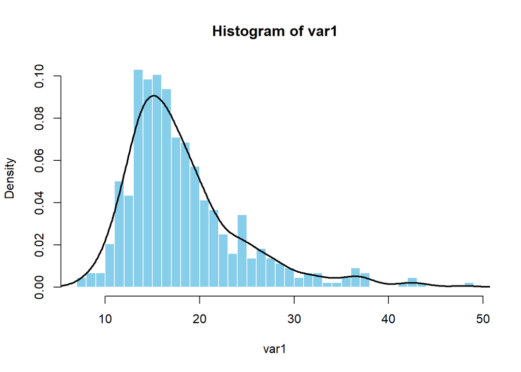

```r
var1 <- df$percollege
hist(var1, breaks = 30, border = "white", col = "skyblue", freq = F)
lines(density(var1, bw = 1.5), lwd = 2)
```

```r
ks.test(var1, "pnorm", mean = mean(var1), sd = sd(var1))
```

```
##
##  One-sample Kolmogorov-Smirnov test
##
## data:  var1
## D = 0.1289, p-value = 9.859e-07
## alternative hypothesis: two-sided
```

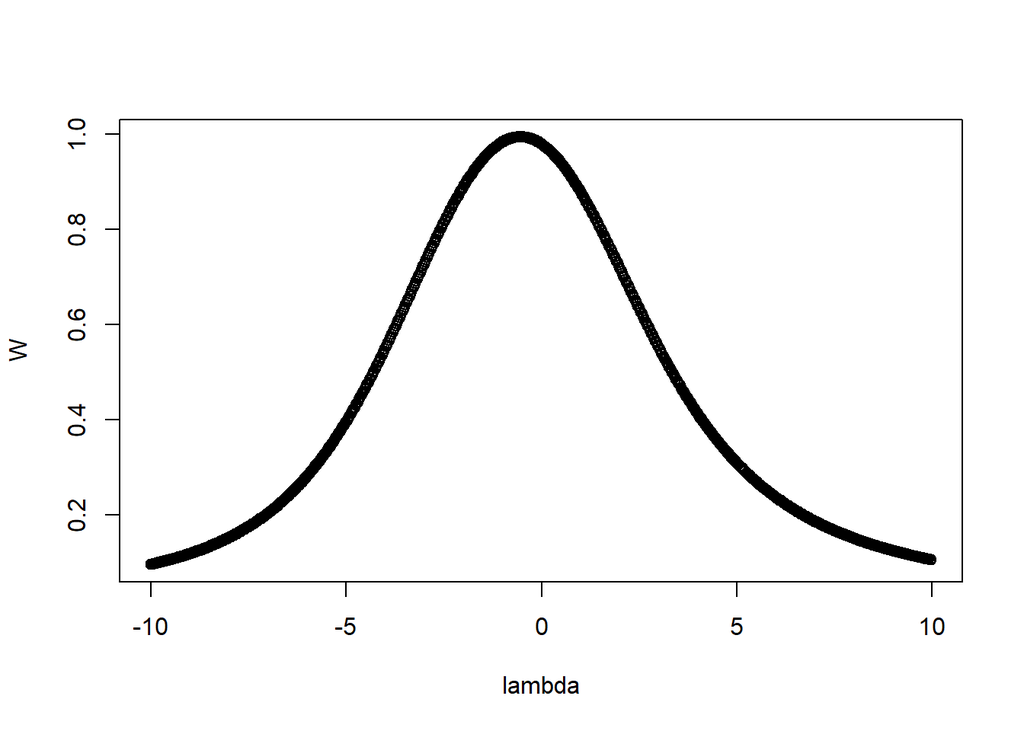

```
##
##     lambda      W Shapiro.p.value
## 379  -0.55 0.9939         0.07677
##
## if (lambda >  0){TRANS = x ^ lambda}
## if (lambda == 0){TRANS = log(x)}
## if (lambda <  0){TRANS = -1 * x ^ lambda}
```

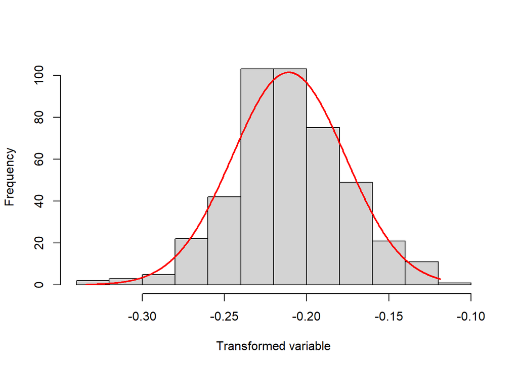

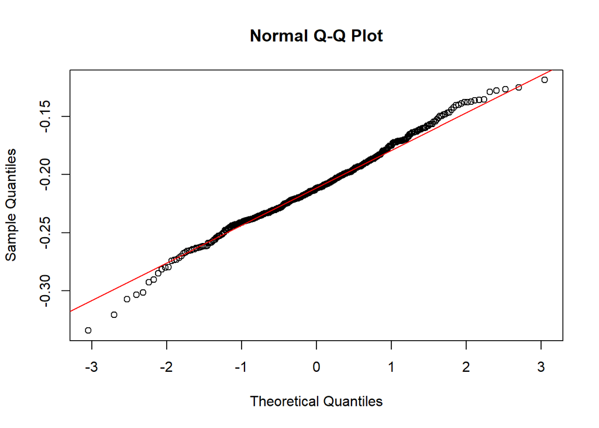

[output not shown]

[output cut: 58 more lines]

```r
library(rcompanion)
transformTukey(var1, returnLambda = F)
```

Tukey: Y* = Y^lambda

```r
var1.tuk <- transformTukey(var1)  # sama dengan var1.tuk <- var1^lambda
```

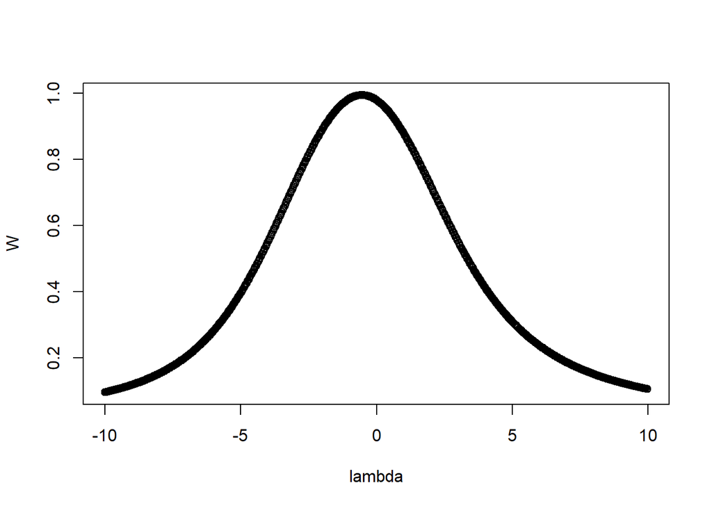

```
##
##     lambda      W Shapiro.p.value
## 379  -0.55 0.9939         0.07677
##
## if (lambda >  0){TRANS = x ^ lambda}
## if (lambda == 0){TRANS = log(x)}
## if (lambda <  0){TRANS = -1 * x ^ lambda}
```

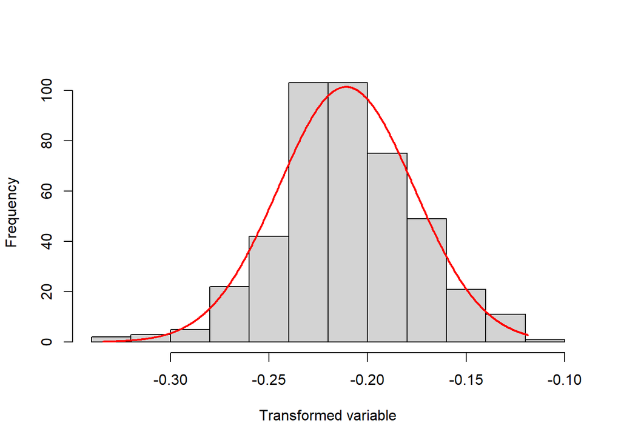

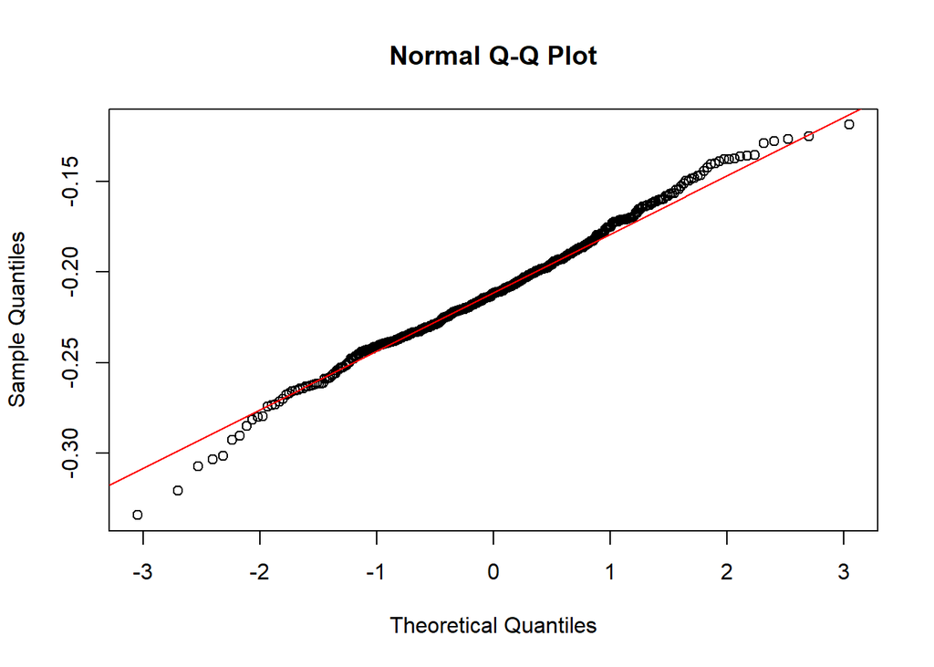

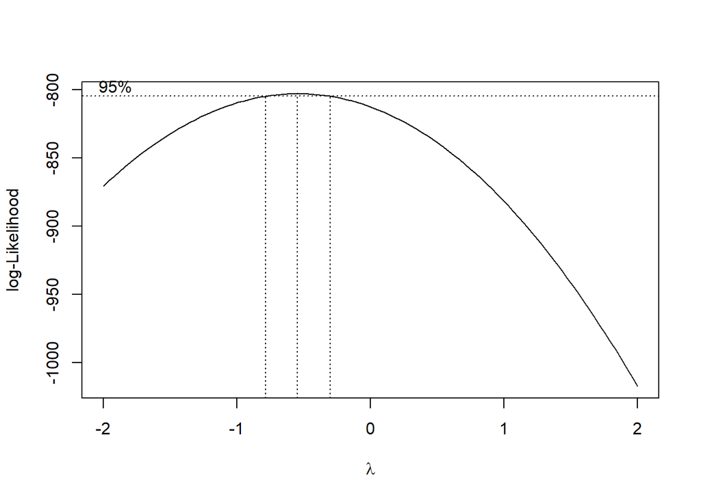

```r
library(MASS)
bc <- boxcox(var1 ~ 1)
```

```r
bc$x[which.max(bc$y)]  # -0.5454545
```

```
## [1] -0.5454545
```

1/sqrt(var1)

```r
lambda <- -.55
var1.bc <- (var1^lambda - 1)/lambda
```

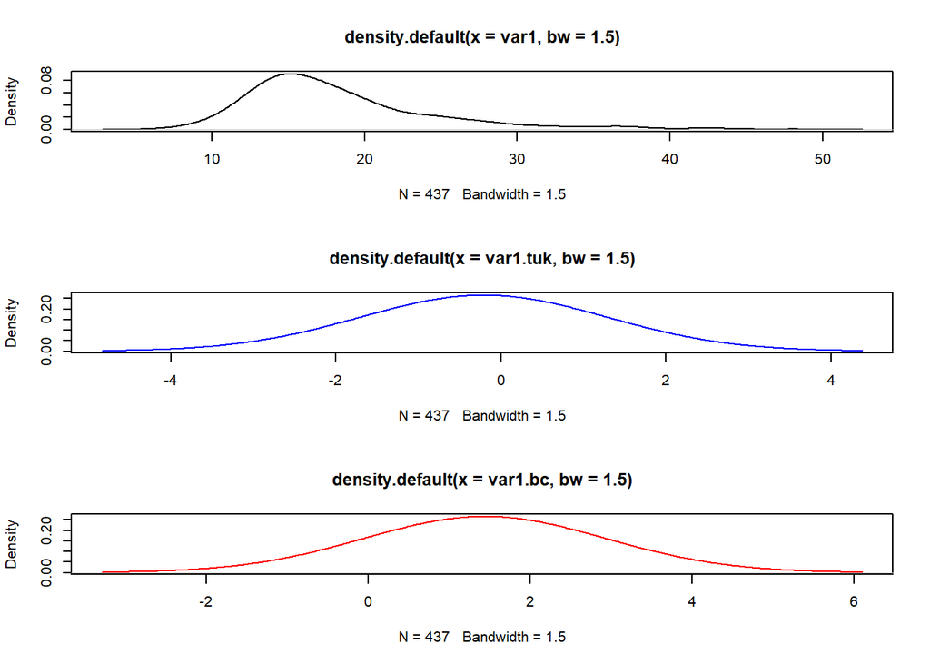

```r
par(mfrow = c(3, 1))
plot(density(var1, bw = 1.5), type = "l")
plot(density(var1.tuk, bw = 1.5), type = "l", col = "blue")
plot(density(var1.bc, bw = 1.5), type = "l", col = "red")
```

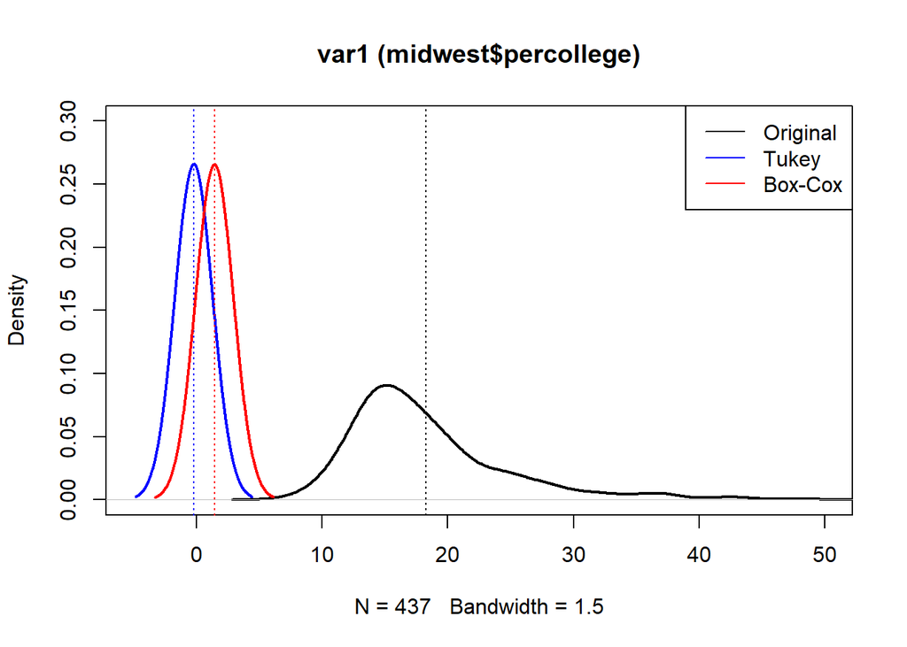

```r
par(mfrow = c(1, 1))
plot(density(var1, bw = 1.5), type = "l", col = "black", lwd = 2,
     xlim = c(-5, 50), ylim = c(0, .3), main = "var1 (midwest$percollege)")
abline(v = mean(var1), col = "black", lty = "dotted")

lines(density(var1.tuk, bw = 1.5), col = "blue", lwd = 2)
abline(v = mean(var1.tuk), col = "blue", lty = "dotted")

lines(density(var1.bc, bw = 1.5), col = "red", lwd = 2)
abline(v = mean(var1.bc), col = "red", lty = "dotted")

legend("topright", legend = c("Original", "Tukey", "Box-Cox"),
       lty = 1, col = c("black", "blue", "red"))
```

Peluang terima H0 KS-Test terhadap sebaran normal cenderung lebih tinggi pada peubah hasil transformasi Tukey dan Box-Cox. Data hasil transformasi menjadi lebih simetris.

```r
ks.test(var1, "pnorm", mean = mean(var1), sd = sd(var1))
```

```
##
##  One-sample Kolmogorov-Smirnov test
##
## data:  var1
## D = 0.1289, p-value = 9.859e-07
## alternative hypothesis: two-sided
```

```r
ks.test(var1.tuk, "pnorm", mean = mean(var1.tuk), sd = sd(var1.tuk))
```

```
##
##  One-sample Kolmogorov-Smirnov test
##
## data:  var1.tuk
## D = 0.038585, p-value = 0.5334
## alternative hypothesis: two-sided
```

```r
ks.test(var1.bc, "pnorm", mean = mean(var1.bc), sd = sd(var1.bc))
```

```
##
##  One-sample Kolmogorov-Smirnov test
##
## data:  var1.bc
## D = 0.038585, p-value = 0.5334
## alternative hypothesis: two-sided
```

### Left-Skewed

Data yang mengumpul di kanan dan menjulur ke kiri dapat dinormalkan/disimetriskan menggunakan pangkat positif.

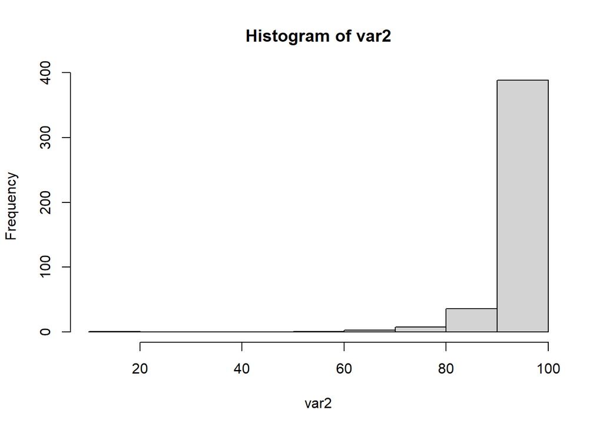

```r
var2 <- df$percwhite
hist(var2)
```

```r
var2.tuk <- transformTukey(var2)
```

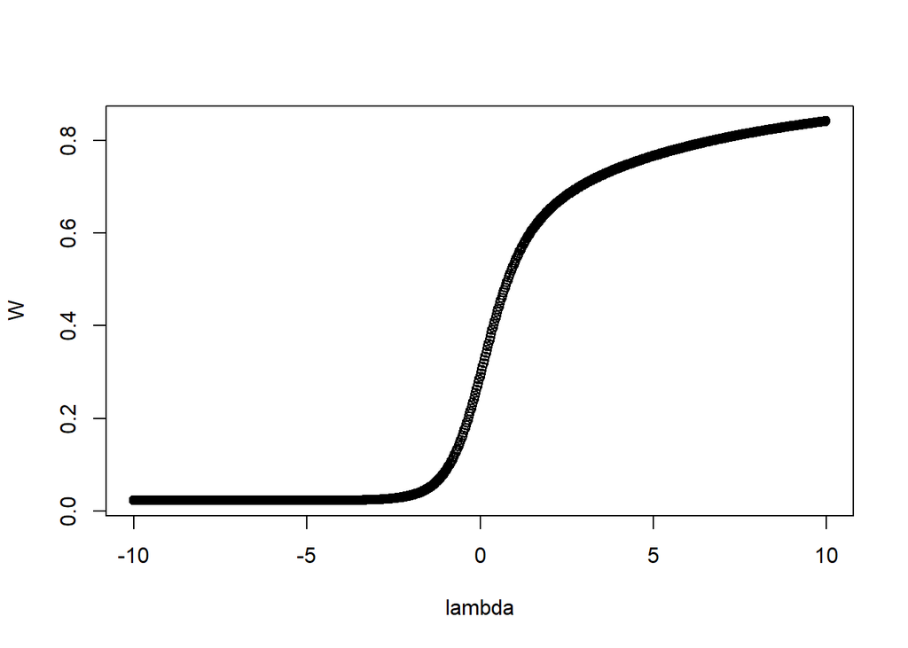

```
##
##     lambda      W Shapiro.p.value
## 800  9.975 0.8409       1.498e-20
##
## if (lambda >  0){TRANS = x ^ lambda}
## if (lambda == 0){TRANS = log(x)}
## if (lambda <  0){TRANS = -1 * x ^ lambda}
```

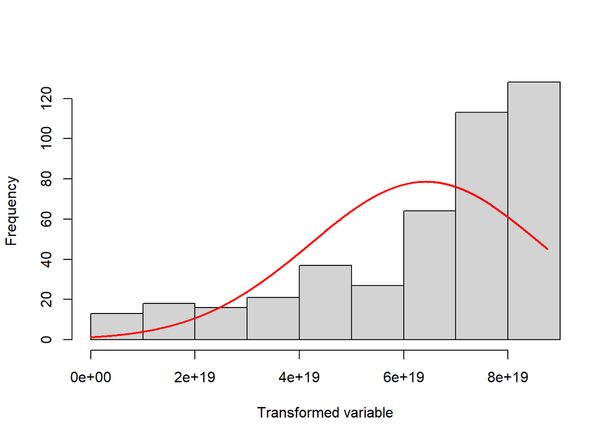

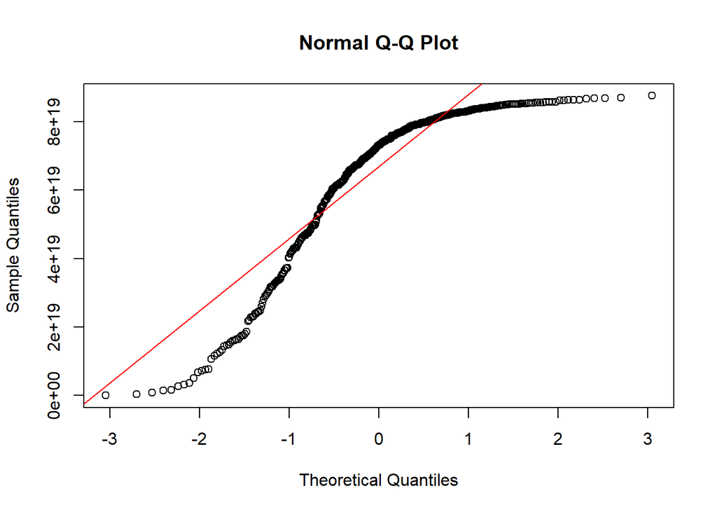

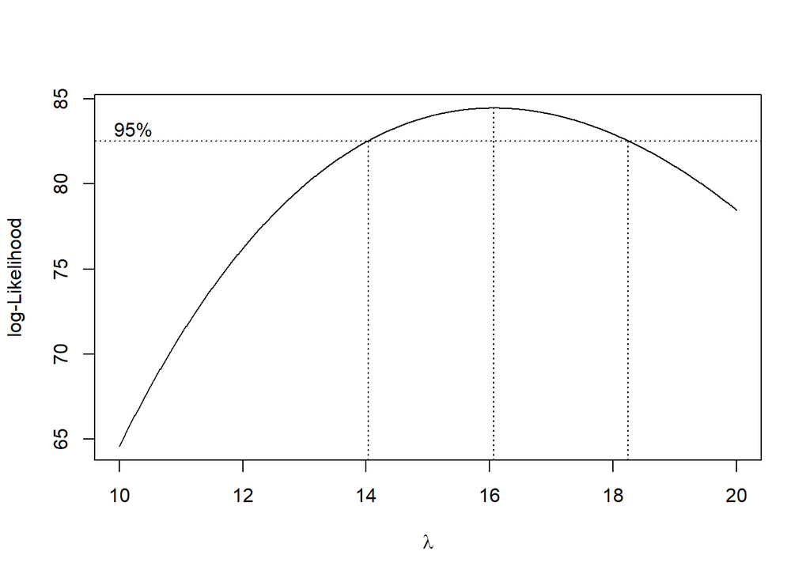

```r
bc2 <- boxcox(var2 ~ 1, seq(10, 20, .01))
```

```r
lambda2 <- bc2$x[which.max(bc2$y)]; lambda2
```

```
## [1] 16.07
```

```r
var2.bc <- (var2^lambda2 - 1)/lambda2
```

Peluang terima H0 KS-Test terhadap sebaran normal cenderung lebih tinggi pada peubah hasil transformasi Tukey dan Box-Cox. Data hasil transformasi menjadi lebih simetris.

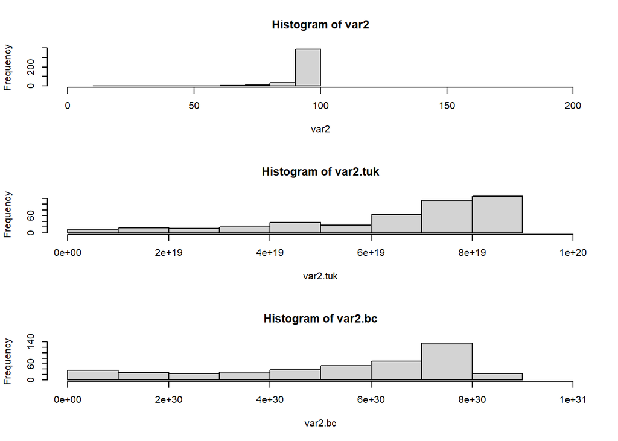

```r
par(mfrow = c(3, 1))
hist(var2, xlim = c(0, 200))
hist(var2.tuk, xlim = c(0, 1e+20))
hist(var2.bc, xlim = c(0, 1e+31))
```

```r
ks.test(var2, "pnorm", mean = mean(var2), sd = sd(var2))
```

```
##
##  One-sample Kolmogorov-Smirnov test
##
## data:  var2
## D = 0.27452, p-value < 2.2e-16
## alternative hypothesis: two-sided
```

```r
ks.test(var2.tuk, "pnorm", mean = mean(var2.tuk), sd = sd(var2.tuk))
```

```
##
##  One-sample Kolmogorov-Smirnov test
##
## data:  var2.tuk
## D = 0.158, p-value = 6.695e-10
## alternative hypothesis: two-sided
```

```r
ks.test(var2.bc, "pnorm", mean = mean(var2.bc), sd = sd(var2.bc))
```

```
##
##  One-sample Kolmogorov-Smirnov test
##
## data:  var2.bc
## D = 0.14286, p-value = 3.587e-08
## alternative hypothesis: two-sided
```

### Kelemahan Transformasi Tukey (di R)

```r
length(var1)  # 437
```

```
## [1] 437
```

```r
var3 <- rep(var1, 20)
length(var3)
```

```
## [1] 8740
```

Bergantung pada fungsi shapiro.test() yang hanya dapat menerima 3 <= n <= 5000, sehingga pada data besar menjadi sulit digunakan.

```r
try(transformTukey(var3))
```

```
## Error in shapiro.test(TRANS) : sample size must be between 3 and 5000
```

## Box-Cox Implementation on Linear Regression Residuals

Transformasi peubah Y untuk mengubah sebaran sisaan menjadi normal. Akan sangat berguna pada regresi OLS parametrik yang mengasumsikan normalitas sebaran residu.

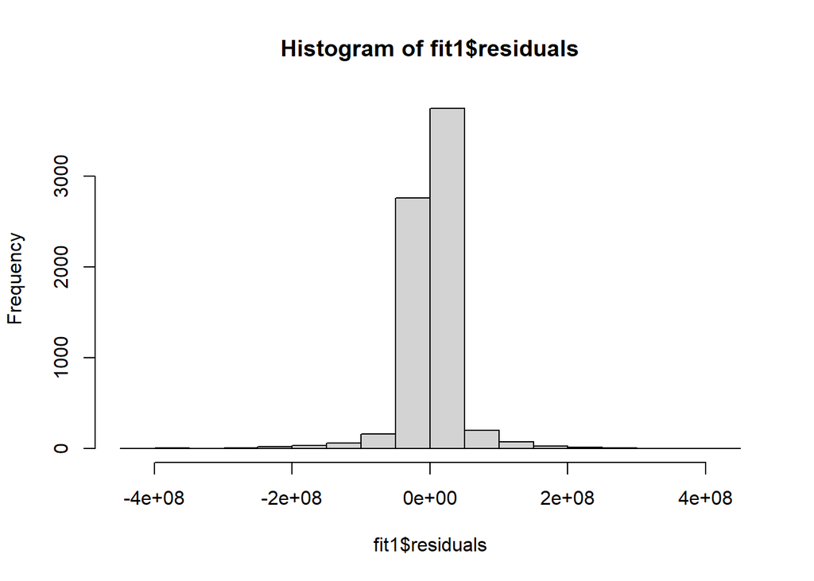

```r
df2 <- ggplot2::txhousing
fit1 <- lm(volume ~ sales + listings + inventory, data = df2)
hist(fit1$residuals)
```

```r
coef(fit1)
```

```
##  (Intercept)        sales     listings    inventory
## -15423381.15    277234.13    -12627.28   1025870.71
```

```r
ks.test(fit1$residuals, "pnorm", mean = 0, sd = sd(fit1$residuals))
```

```
##
##  One-sample Kolmogorov-Smirnov test
##
## data:  fit1$residuals
## D = 0.23735, p-value < 2.2e-16
## alternative hypothesis: two-sided
```

volume = -15423381 + 277234 x sales - 12627 x listings + 1025870 x inventory

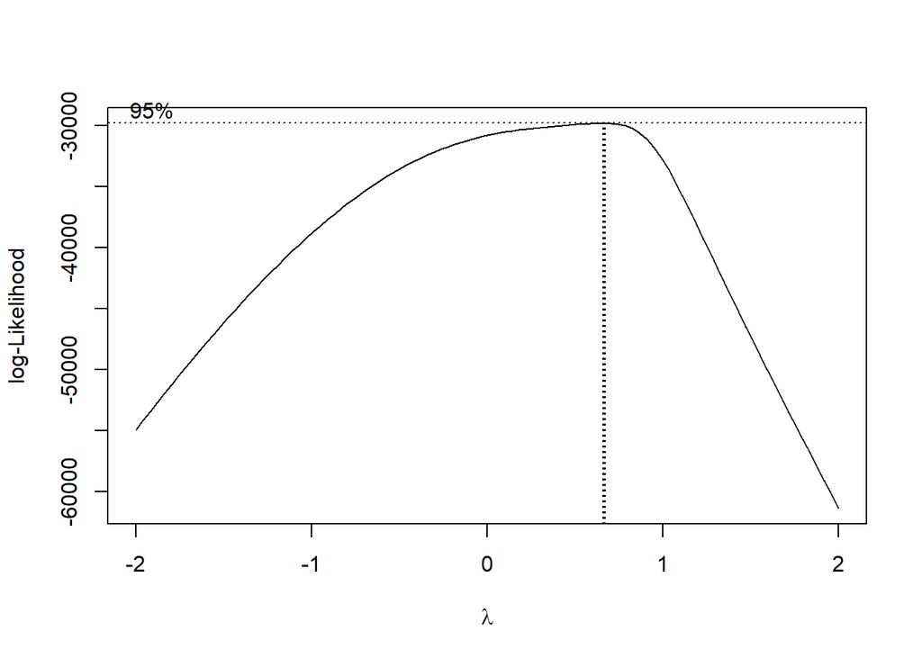

```r
bc3 <- boxcox(fit1)
```

```r
bc3$x[which.max(bc3$y)]
```

```
## [1] 0.6666667
```

```r
lambda3 <- bc3$x[which.max(bc3$y)] # 0.67
```

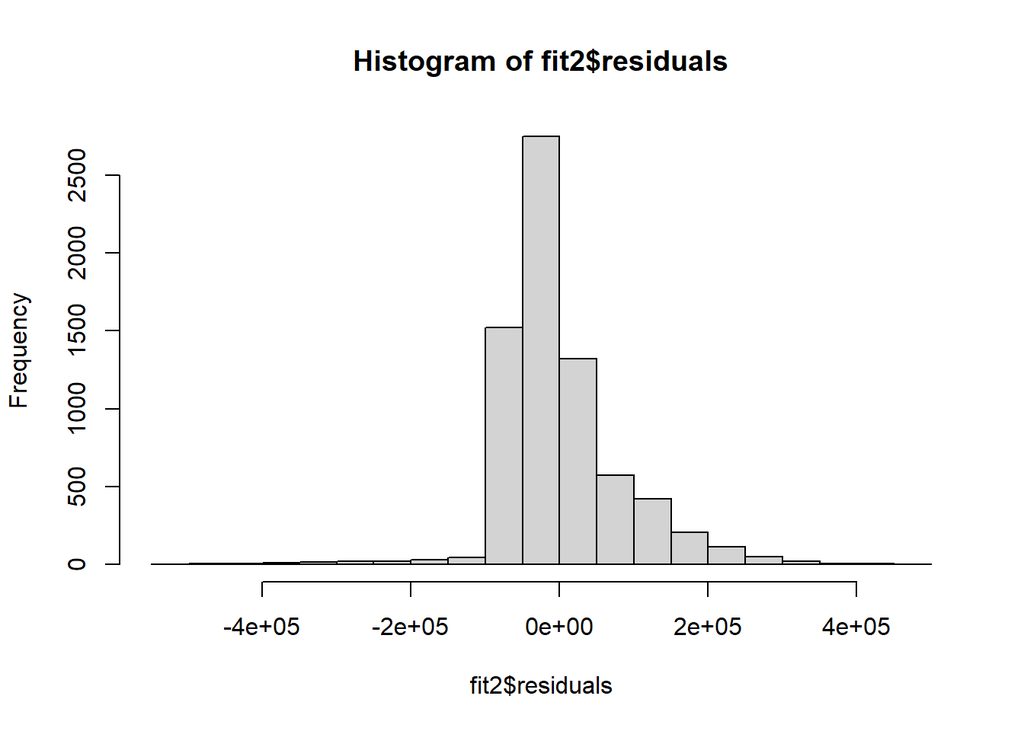

```r
fit2 <- lm(((volume)^lambda3 - 1)/lambda3 ~ sales + listings + inventory,
           data = df2)
hist(fit2$residuals)
```

```r
ks.test(fit1$residuals, "pnorm", mean = 0, sd = sd(fit1$residuals))
```

```
##
##  One-sample Kolmogorov-Smirnov test
##
## data:  fit1$residuals
## D = 0.23735, p-value < 2.2e-16
## alternative hypothesis: two-sided
```

```r
ks.test(fit2$residuals, "pnorm", mean = 0, sd = sd(fit2$residuals))
```

```
##
##  One-sample Kolmogorov-Smirnov test
##
## data:  fit2$residuals
## D = 0.14148, p-value < 2.2e-16
## alternative hypothesis: two-sided
```

```r
set.seed(42)
kSamples::ad.test(fit1$residuals,
                  rnorm(n = length(fit1$residuals), sd = sd(fit1$residuals)))
```

```
##
##
##  Anderson-Darling k-sample test.
##
## Number of samples:  2
## Sample sizes:  7134, 7134
## Number of ties: 2
##
## Mean of  Anderson-Darling  Criterion: 1
## Standard deviation of  Anderson-Darling  Criterion: 0.7613
##
## T.AD = ( Anderson-Darling  Criterion - mean)/sigma
##
## Null Hypothesis: All samples come from a common population.
##
##               AD  T.AD  asympt. P-value
## version 1: 445.1 583.3       1.069e-244
## version 2: 445.0 583.3       7.297e-244
```

```r
set.seed(42)
kSamples::ad.test(fit2$residuals,
                  rnorm(n = length(fit2$residuals), sd = sd(fit2$residuals)))
```

```
##
##
##  Anderson-Darling k-sample test.
##
## Number of samples:  2
## Sample sizes:  7134, 7134
## Number of ties: 2
##
## Mean of  Anderson-Darling  Criterion: 1
## Standard deviation of  Anderson-Darling  Criterion: 0.7613
##
## T.AD = ( Anderson-Darling  Criterion - mean)/sigma
##
## Null Hypothesis: All samples come from a common population.
##
##               AD  T.AD  asympt. P-value
## version 1: 164.4 214.6        1.652e-90
## version 2: 164.0 214.6        3.242e-90
```

Tidak selamanya hasil transformasi akan berhasil, namun setidaknya kita dapat mendekati sebaran normal dan metode ini dapat digunakan di lain kasus.

## FitdistrPlus

Dapat digunakan untuk mencari parameter-parameter terbaik dari suatu fungsi sebaran.

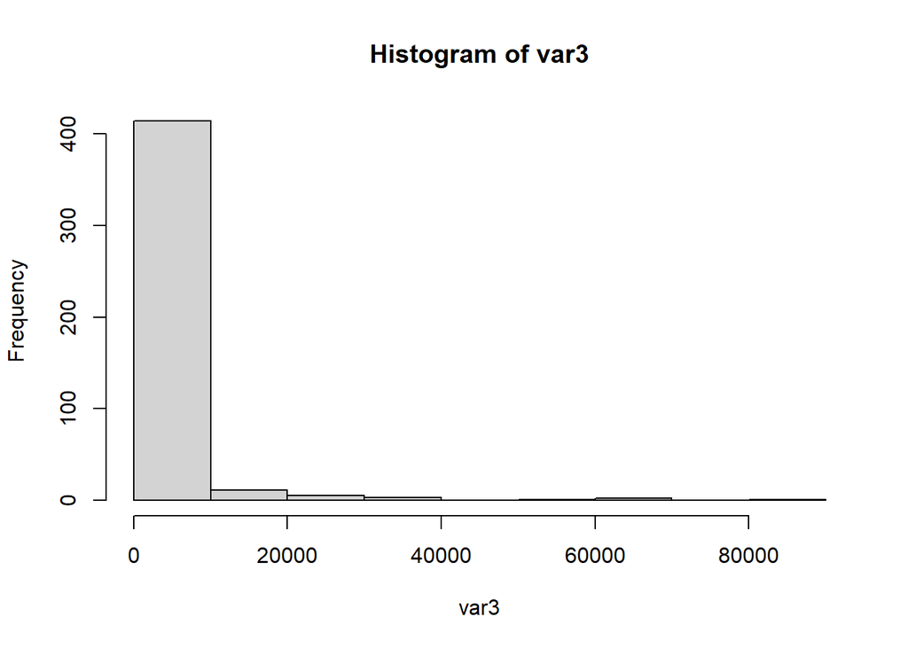

```r
var3 <- df$popdensity
#plot(density(var3, bw = 10), type = "l")
hist(var3)
```

```r
library(fitdistrplus)
fdLogis <- fitdist(var3, "logis")
fdLogis$estimate
```

```
## location    scale
## 1819.424 1938.262
```

```r
ks.test(var3, "plogis", fdLogis$estimate[1], fdLogis$estimate[2])
```

```
##
##  One-sample Kolmogorov-Smirnov test
##
## data:  var3
## D = 0.29012, p-value < 2.2e-16
## alternative hypothesis: two-sided
```

```r
fdF <- fitdist(var3, "f", start = list(df1 = 10, df2 = 10), method = 'mse')
fdF$estimate
```

```
##          df1          df2
## 1.407312e+04 2.536784e-01
```

```r
ks.test(var3, "pf", fdF$estimate[1], fdF$estimate[2])
```

```
##
##  One-sample Kolmogorov-Smirnov test
##
## data:  var3
## D = 0.55498, p-value < 2.2e-16
## alternative hypothesis: two-sided
```

```r
fdLogNorm <- fitdist(var3, "lnorm")
fdLogNorm$estimate
```

```
##  meanlog    sdlog
## 7.191311 1.123345
```

```r
ks.test(var3, "plnorm", fdLogNorm$estimate[1], fdLogNorm$estimate[2])
```

```
##
##  One-sample Kolmogorov-Smirnov test
##
## data:  var3
## D = 0.081382, p-value = 0.006125
## alternative hypothesis: two-sided
```